# chicago cyclistic bike-share Analysis

Boluwatife Daniel Afe

2023-04-22

#Load the packages

```r
library(tidyverse)#wrangle data
```

```r
library(dplyr) #cleandata
library(lubridate) #wrangle data attributes
library(ggplot2) #visualize data
library(readr)
library(skimr)#get summary of data
```

#STEP 1:prepare the data and comn=bine them in one data frame

```r
getwd()
```

```
## [1] "/Users/macbookpro/Downloads/CYCLISTIC"
```

```r
setwd("/Users/macbookpro/Downloads/CYCLISTIC")
```

#STEP 2:combine the data from september 2020 to August 2021 into one data frame

```r
bike_data <- rbind(
  read_csv("202009-divvy-tripdata.csv"),
  read_csv("202010-divvy-tripdata.csv"),
  read_csv("202011-divvy-tripdata.csv"),
  read_csv("202012-divvy-tripdata.csv"),
  read_csv("202101-divvy-tripdata.csv"),
  read_csv("202102-divvy-tripdata.csv"),
  read_csv("202103-divvy-tripdata.csv"),
  read_csv("202104-divvy-tripdata.csv"),
  read_csv("202105-divvy-tripdata.csv"),
  read_csv("202106-divvy-tripdata.csv"),
  read_csv("202107-divvy-tripdata.csv"),
  read_csv("202108-divvy-tripdata.csv")
)
```

#STEP 3: Examine the data frame

```r
head(bike_data)  #to get the first few records from all the columns displayed
```

```
## # A tibble: 6 × 13
##   ride_id          rideable_type started_at          ended_at
##   <chr>            <chr>         <dttm>              <dttm>
## 1 2B22BD5F95FB2629 electric_bike 2020-09-17 14:27:11 2020-09-17 14:44:24
## 2 A7FB70B4AFC6CAF2 electric_bike 2020-09-17 15:07:31 2020-09-17 15:07:45
## 3 86057FA01BAC778E electric_bike 2020-09-17 15:09:04 2020-09-17 15:09:35
## 4 57F6DC9A153DB98C electric_bike 2020-09-17 18:10:46 2020-09-17 18:35:49
## 5 B9C4712F78C1AE68 electric_bike 2020-09-17 15:16:13 2020-09-17 15:52:55
## 6 378BBCE1E444EB80 electric_bike 2020-09-17 18:37:04 2020-09-17 19:23:28
## # ℹ 9 more variables: start_station_name <chr>, start_station_id <chr>,
## #   end_station_name <chr>, end_station_id <chr>, start_lat <dbl>,
## #   start_lng <dbl>, end_lat <dbl>, end_lng <dbl>, member_casual <chr>
```

```r
dim(bike_data) #to show the number of rows and columns the data frame has
```

```
## [1] 4913072      13
```

```r
colnames(bike_data) #to identify all the colums in the bike_data
```

```
##  [1] "ride_id"            "rideable_type"      "started_at"
##  [4] "ended_at"           "start_station_name" "start_station_id"
##  [7] "end_station_name"   "end_station_id"     "start_lat"
## [10] "start_lng"          "end_lat"            "end_lng"
## [13] "member_casual"
```

```r
summary(bike_data) #to generate descriptive statistics of a data object e.g mean, median
```

```
##    ride_id          rideable_type        started_at
##  Length:4913072     Length:4913072     Min.   :2020-09-01 00:00:07.00
##  Class :character   Class :character   1st Qu.:2020-12-09 18:57:27.50
##  Mode  :character   Mode  :character   Median :2021-05-26 16:51:05.50
##                                        Mean   :2021-04-11 06:27:48.92
##                                        3rd Qu.:2021-07-17 03:36:04.00
##                                        Max.   :2021-08-31 23:59:35.00
##
##     ended_at                      start_station_name start_station_id
##  Min.   :2020-09-01 00:04:43.00   Length:4913072     Length:4913072
##  1st Qu.:2020-12-09 18:29:54.25   Class :character   Class :character
##  Median :2021-05-26 17:12:45.50   Mode  :character   Mode  :character
##  Mean   :2021-04-11 06:48:57.59
##  3rd Qu.:2021-07-17 04:16:25.75
##  Max.   :2021-09-01 17:37:35.00
##
##  end_station_name   end_station_id       start_lat       start_lng
##  Length:4913072     Length:4913072     Min.   :41.64   Min.   :-87.84
##  Class :character   Class :character   1st Qu.:41.88   1st Qu.:-87.66
##  Mode  :character   Mode  :character   Median :41.90   Median :-87.64
##                                        Mean   :41.90   Mean   :-87.65
##                                        3rd Qu.:41.93   3rd Qu.:-87.63
##                                        Max.   :42.08   Max.   :-87.52
##
##     end_lat         end_lng       member_casual
##  Min.   :41.51   Min.   :-88.07   Length:4913072
##  1st Qu.:41.88   1st Qu.:-87.66   Class :character
##  Median :41.90   Median :-87.64   Mode  :character
##  Mean   :41.90   Mean   :-87.64
##  3rd Qu.:41.93   3rd Qu.:-87.63
##  Max.   :42.15   Max.   :-87.44
##  NA's   :5015    NA's   :5015
```

#STEP 4: check for the null values(NA)

```r
sum(is.na(bike_data)) #choosing not to remove NA because most NA are related to the start and end station names
```

```
## [1] 1893790
```

#STEP 5: drop the columns we don’t need : start_lat, start_lng,end_lat,end_lng

```r
bike_data <- bike_data %>%
  select(-c(start_lat,start_lng,end_lat,end_lng))
colnames(bike_data)
```

```
## [1] "ride_id"            "rideable_type"      "started_at"
## [4] "ended_at"           "start_station_name" "start_station_id"
## [7] "end_station_name"   "end_station_id"     "member_casual"
```

```r
bike_data <- bike_data %>%
  mutate(ride_length = ended_at - started_at) %>%
  mutate(day_of_the_week = weekdays(as.Date(bike_data$started_at)))

#convert ride_length from seconds into minutes
bike_data$ride_length <- as.numeric(bike_data$ride_length)
bike_data$ride_length <- as.numeric(bike_data$ride_length/60)
head(bike_data)
```

```
## # A tibble: 6 × 11
##   ride_id          rideable_type started_at          ended_at
##   <chr>            <chr>         <dttm>              <dttm>
## 1 2B22BD5F95FB2629 electric_bike 2020-09-17 14:27:11 2020-09-17 14:44:24
## 2 A7FB70B4AFC6CAF2 electric_bike 2020-09-17 15:07:31 2020-09-17 15:07:45
## 3 86057FA01BAC778E electric_bike 2020-09-17 15:09:04 2020-09-17 15:09:35
## 4 57F6DC9A153DB98C electric_bike 2020-09-17 18:10:46 2020-09-17 18:35:49
## 5 B9C4712F78C1AE68 electric_bike 2020-09-17 15:16:13 2020-09-17 15:52:55
## 6 378BBCE1E444EB80 electric_bike 2020-09-17 18:37:04 2020-09-17 19:23:28
## # ℹ 7 more variables: start_station_name <chr>, start_station_id <chr>,
## #   end_station_name <chr>, end_station_id <chr>, member_casual <chr>,
## #   ride_length <dbl>, day_of_the_week <chr>
```

#STEP 7:removing the bad data and doing analysis on the ride_length column #check for the data with negative ride_length

```r
bike_data <- bike_data[bike_data$ride_length>0,]
```

```r
#check for data with ride_length more than 1 day (1440minutes).3484 rides went down for more than one day
sum(bike_data$ride_length > 1440)
```

```
## [1] 3484
```

```r
#check for extreme ontliner:55944.15 minutes or 38.83 days for the max ride and less than 1sec for the least ride
min(bike_data$ride_length)
```

```
## [1] 0.01666667
```

```r
max(bike_data$ride_length)
```

```
## [1] 55944.15
```

```r
#check the mean and median
mean(bike_data$ride_length)
```

```
## [1] 23.37355
```

```r
median(bike_data$ride_length)
```

```
## [1] 12.81667
```

#STEP 8: Aggregate to analyze the data based on user type: member vs casual

```r
aggregate(bike_data$ride_length ~ bike_data$member_casual, FUN = mean)
```

```
##   bike_data$member_casual bike_data$ride_length
## 1                  casual              34.22207
## 2                  member              14.38568
```

```r
aggregate(bike_data$ride_length ~ bike_data$member_casual, FUN = median)
```

```
##   bike_data$member_casual bike_data$ride_length
## 1                  casual                 17.15
## 2                  member                 10.25
```

```r
#Average ride time by each day for memebers vs casuals
bike_data$day_of_the_week <- ordered(bike_data$day_of_the_week, levels=c("Sunday","Monday","Tuesday","Wednesday","Thursday","Friday","Saturday"))
aggregate(bike_data$ride_length ~ bike_data$member_casual + bike_data$day_of_the_week, FUN = mean)
```

```
##    bike_data$member_casual bike_data$day_of_the_week bike_data$ride_length
## 1                   casual                    Sunday              39.51034
## 2                   member                    Sunday              16.38429
## 3                   casual                    Monday              33.80024
## 4                   member                    Monday              13.84208
## 5                   casual                   Tuesday              30.31969
## 6                   member                   Tuesday              13.53984
## 7                   casual                 Wednesday              30.47083
## 8                   member                 Wednesday              13.61779
## 9                   casual                  Thursday              29.61900
## 10                  member                  Thursday              13.46982
## 11                  casual                    Friday              32.69864
## 12                  member                    Friday              14.18940
## 13                  casual                  Saturday              36.96224
## 14                  member                  Saturday              15.95073
```

#STEP 9:Further Analysis into the stations, which shows where NA belongs in step IV

```r
head(count(bike_data, start_station_name, member_casual, rideable_type, sort = TRUE))
```

```
## # A tibble: 6 × 4
##   start_station_name      member_casual rideable_type      n
##   <chr>                   <chr>         <chr>          <int>
## 1 <NA>                    member        electric_bike 232959
## 2 <NA>                    casual        electric_bike 217028
## 3 Streeter Dr & Grand Ave casual        classic_bike   28270
## 4 Streeter Dr & Grand Ave casual        docked_bike    19865
## 5 Clark St & Elm St       member        classic_bike   13631
## 6 Michigan Ave & Oak St   casual        classic_bike   13285
```

```r
head(count(bike_data, end_station_name, member_casual, rideable_type, sort = TRUE))
```

```
## # A tibble: 6 × 4
##   end_station_name        member_casual rideable_type      n
##   <chr>                   <chr>         <chr>          <int>
## 1 <NA>                    casual        electric_bike 248918
## 2 <NA>                    member        electric_bike 234309
## 3 Streeter Dr & Grand Ave casual        classic_bike   28413
## 4 Streeter Dr & Grand Ave casual        docked_bike    22080
## 5 Michigan Ave & Oak St   casual        classic_bike   14003
## 6 Clark St & Elm St       member        classic_bike   13761
```

#STEP 10: analyze ridership by type and weekday

```r
bike_data %>%
  mutate(weekday = wday(started_at, label = TRUE)) %>% #creates weekday field using wday()
  group_by(member_casual, weekday) %>% #groups by usertype and weekday
  summarise(number_of_rides = n(),          #calculates the number of rides
            average_duration = mean(ride_length)) %>% #calculates the average duration
  arrange(member_casual, weekday)     #sorts
```

```
## # A tibble: 14 × 4
## # Groups:   member_casual [2]
##    member_casual weekday number_of_rides average_duration
##    <chr>         <ord>             <int>            <dbl>
##  1 casual        Sun              420321             39.5
##  2 casual        Mon              250430             33.8
##  3 casual        Tue              242192             30.3
##  4 casual        Wed              241791             30.5
##  5 casual        Thu              247861             29.6
##  6 casual        Fri              322122             32.7
##  7 casual        Sat              498747             37.0
##  8 member        Sun              337163             16.4
##  9 member        Mon              364509             13.8
## 10 member        Tue              399884             13.5
## 11 member        Wed              406382             13.6
## 12 member        Thu              390352             13.5
## 13 member        Fri              395838             14.2
## 14 member        Sat              389634             16.0
```

#STEP 11: visualize the number of rides by rider types and average duration

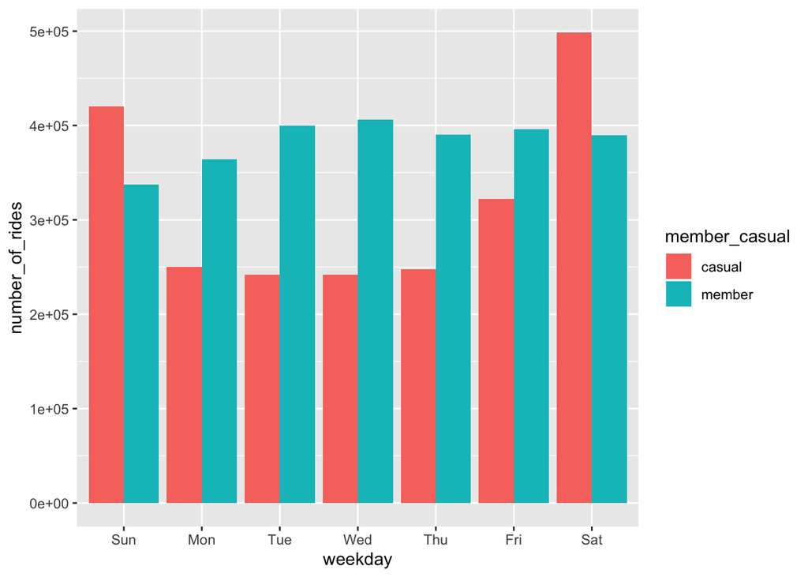

```r
par(mfrow=c(2,2)) ##create a grid of plots with 2 rows and 2 columns.

bike_data %>%
  mutate(weekday = wday(started_at, label = TRUE)) %>%
  group_by(member_casual,weekday)%>%
  summarise(number_of_rides = n(), average_duration = mean(ride_length)) %>%
  arrange(member_casual, weekday) %>%
  ggplot(aes(x=weekday, y=number_of_rides, fill= member_casual))+
  geom_col(position = "dodge")
```

#STEP 12:visualize memeber vs casual on short ride (less and one hour)

[figure not shown]

```r
one_hour_data <- bike_data %>% filter(ride_length < 60)
one_hour_data$ride_length_by_mins <- cut(one_hour_data$ride_length, breaks = 20)

ggplot(data = one_hour_data)+
  geom_bar(mapping = aes(x = ride_length_by_mins, fill= member_casual)) +
  labs(title = "one hour ride length") +
  theme(axis.text.x = element_text(angle = 90, vjust = 0.5,hjust = 1))+
  scale_x_discrete(labels=c("3", "6","9","12", "15","18","21","24","27","30","33","39","42","45","48","51","54","57","60"))
```

#STEP 13: visualize day of the week riding choices between member vs casual

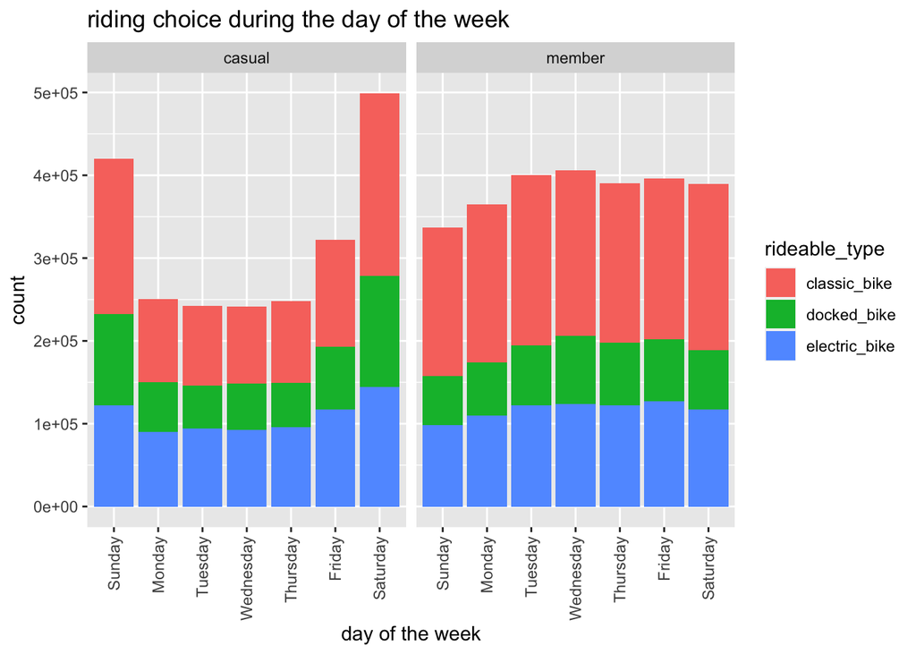

```r
ggplot(data = bike_data) +
  geom_bar(mapping = aes(x = factor(day_of_the_week),fill= rideable_type))+
  facet_wrap(~member_casual)+
  labs(title = 'riding choice during the day of the week', x= 'day of the week')+
  theme(axis.text.x = element_text(angle = 90, vjust = 0.5, hjust = 1))
```

#STEP 14:check for peak time for bike usage between member vs casual

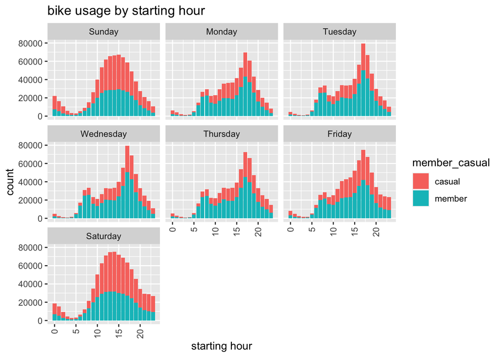

```r
hour_data <- bike_data
hour_data$start_hour <- as.numeric(format(strptime(bike_data$started_at,"%Y-%m-%d %H:%M:%OS"),'%H'))

ggplot(data = hour_data) +
  geom_bar(mapping = aes(x=start_hour, fill = member_casual), stat = 'count')+
  facet_wrap(~factor(day_of_the_week))+
  labs(title = "bike usage by starting hour", x="starting hour")+
  theme(axis.text.x = element_text(angle= 90, vjust = 0.5, hjust = 1))
```

#STEP 15:save as csv for further analysis and visualization in tableau

```r
#the data frame
write_csv(bike_data,"bikedata.csv")

#total and average weekly rides by rider type
summary_ride_weekly <- bike_data %>%
  mutate(weekday = wday(started_at, label = TRUE )) %>%
  group_by(member_casual, weekday) %>%
  summarise(number_of_rides = n(),
            average_duration = mean(ride_length))%>%
  arrange(member_casual, weekday)
write_csv(summary_ride_weekly,"summary_ride_weekly.csv")

#total and average weekly rides by rider type
summary_ride_weekly <- bike_data %>%
  mutate(weekday = wday(started_at, label = TRUE )) %>%
  group_by(member_casual, weekday, rideable_type) %>%
  summarise(number_of_rides = n(),
            average_duration = mean(ride_length))%>%
  arrange(member_casual, weekday)
write_csv(summary_ride_weekly,"summary_ride_weekly_type.csv")

#total and average monthly rides by rider type
summary_month <- bike_data %>%
  mutate(month = month(started_at, label = TRUE )) %>%
  group_by(month,member_casual) %>%
  summarise(number_of_rides = n(),
            average_duration = mean(ride_length))%>%
  arrange(month,member_casual)
write_csv(summary_ride_weekly,"summary_ride_monthly.csv")


#most popular stations
popular_stations <- bike_data %>%
  mutate(station = start_station_name) %>%
  drop_na(start_station_name) %>%
  group_by(start_station_name, member_casual) %>%
  summarise(number_of_rides=n())
write.csv(popular_stations, "popular_stations.csv")

#total memebership types and rideable types
total_riders <- data.frame(table(bike_data$member_casual))
total_types <- data.frame(table(bike_data$rideable_type))

write_csv(total_riders, "total_riders.csv")
write_csv(total_types, "total_types.csv")
```